# Structural divergence - normal modes

# Introduction

In this report we compare structural divergence along normal mode coordinates. Pn is the divergence along a normal mode relative to the mean.

### Fitted Pn vs mode energy and mode number

In this section we compare Pn fitted data. Lines are the median, 0.05 and 0.95 quantiles fit using rq(Pn ~ sn2). sn2 = 1/energy is the expected MSD along mode n. The mean value of Pn should be a linear function of sn2.

[figure not shown]

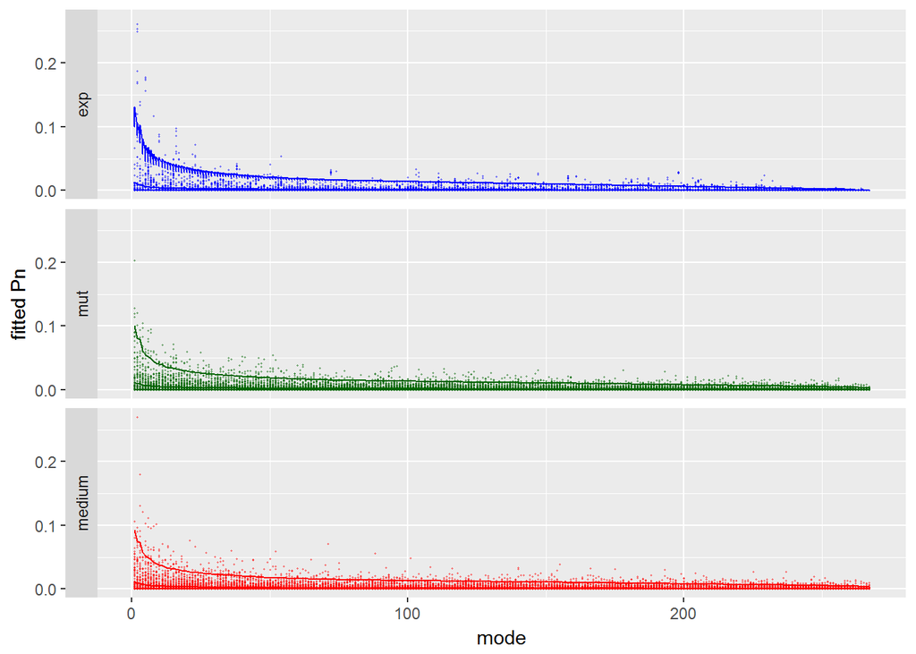

### median Pn and rq.5 vs mode energy and mode number

In this section we compare median Pn and rq.5 profiles with mode energy and mode number.

[figure not shown]

[figure not shown]

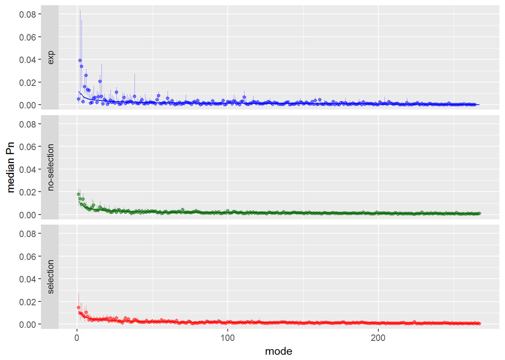

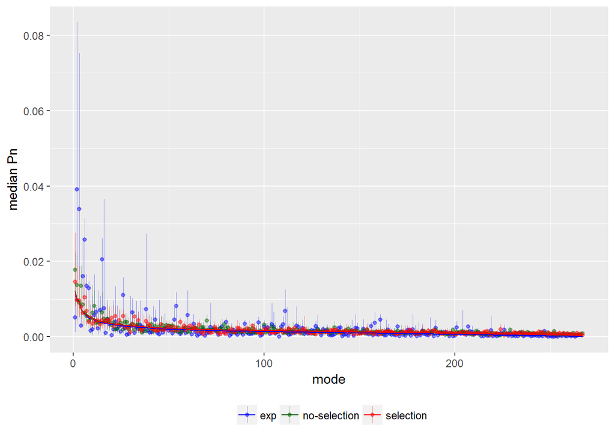

### Comparison and correlation between mean profiles

(calculated for all modes) In this section we compare mean Pn profiles.

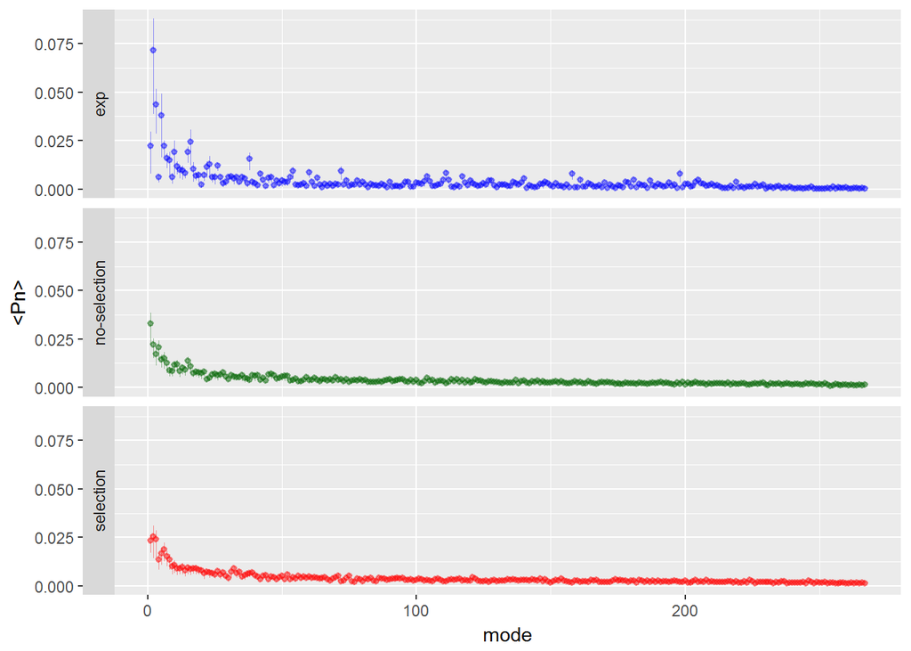

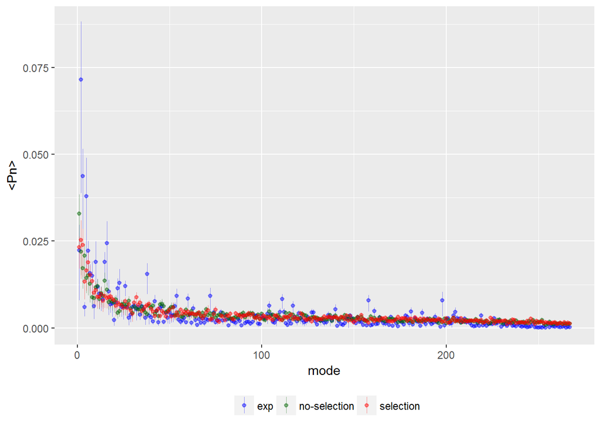

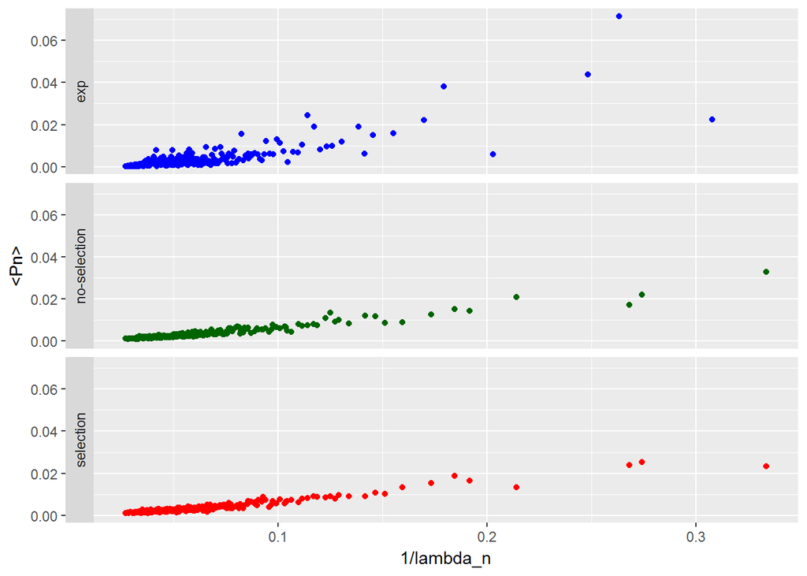

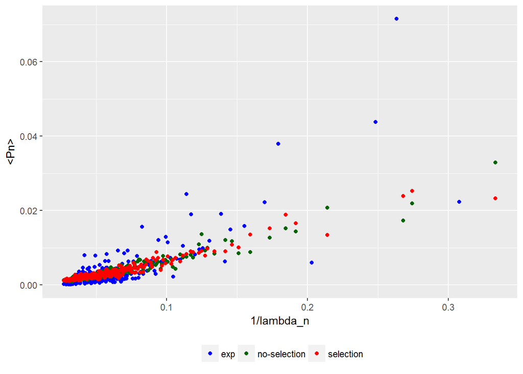

(calculated for the first 100 modes)

| comparison.Pn.Sn2 | R |
| --- | --- |
| exp | 0.80 |
| mut | 0.96 |
| medium | 0.96 |

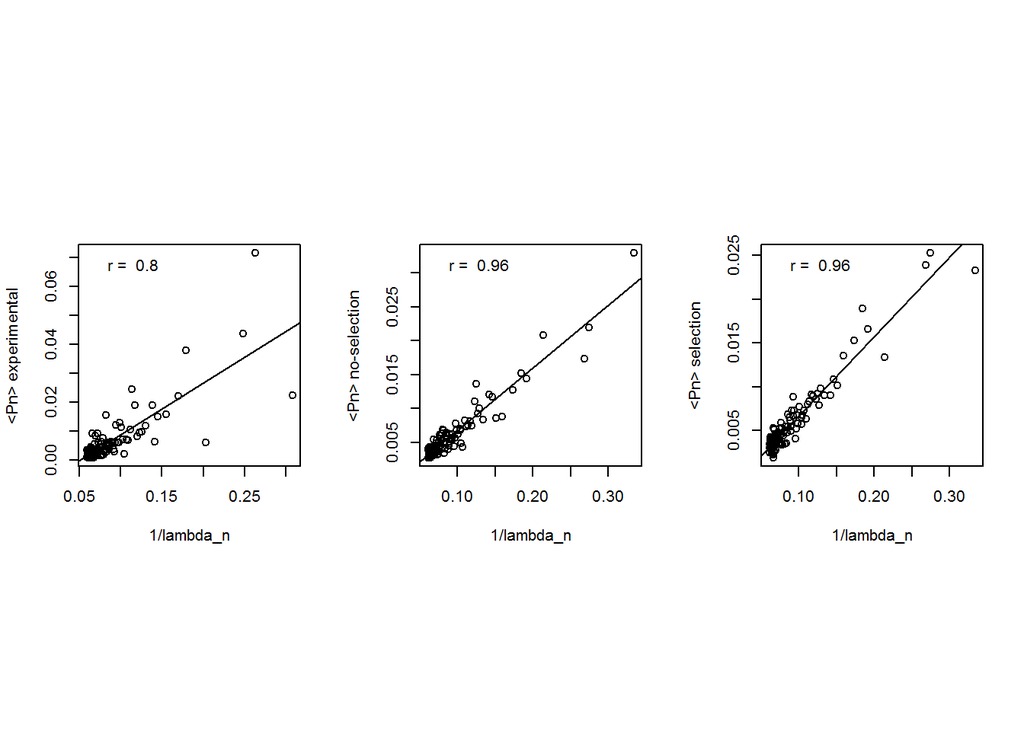

| comparison.Pn.100.modes | R |
| --- | --- |
| exp vs mut | 0.71 |
| exp vs medium | 0.84 |
| mut vs medium | 0.90 |

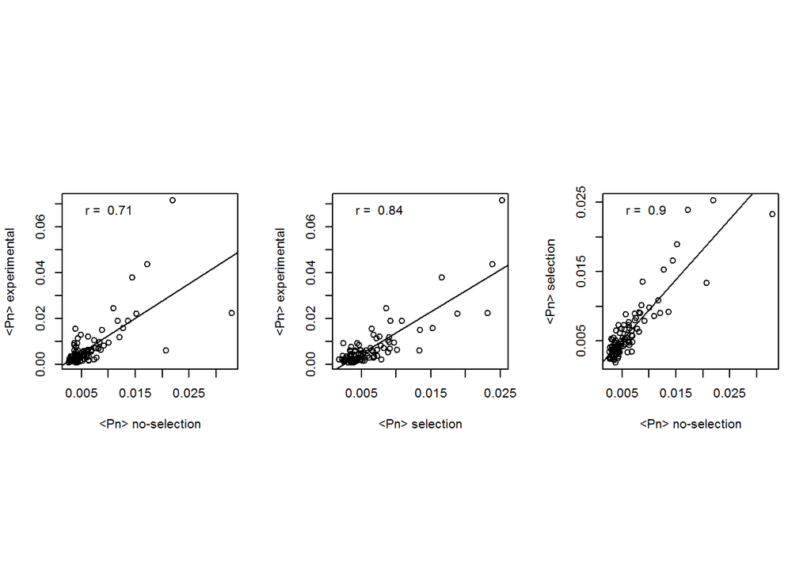

### Comparison and correlation between median mode profiles

(calculated for all modes) In this section we compare median Pn profiles.

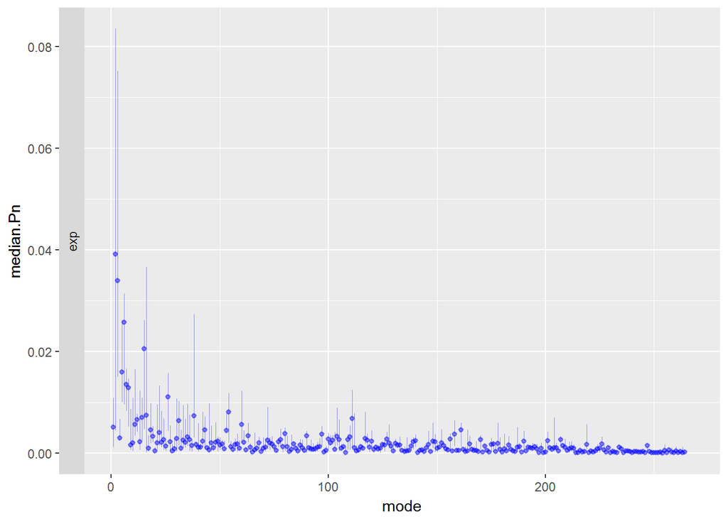

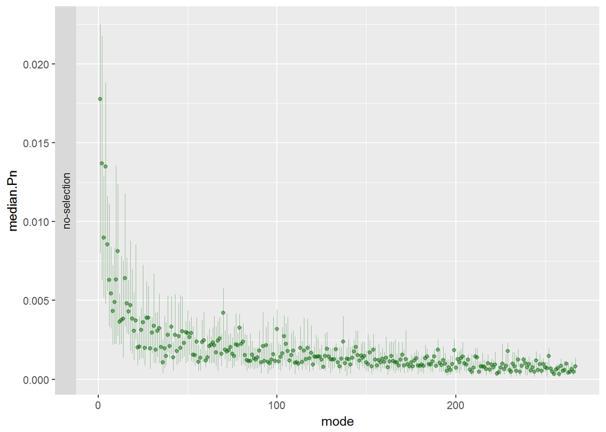

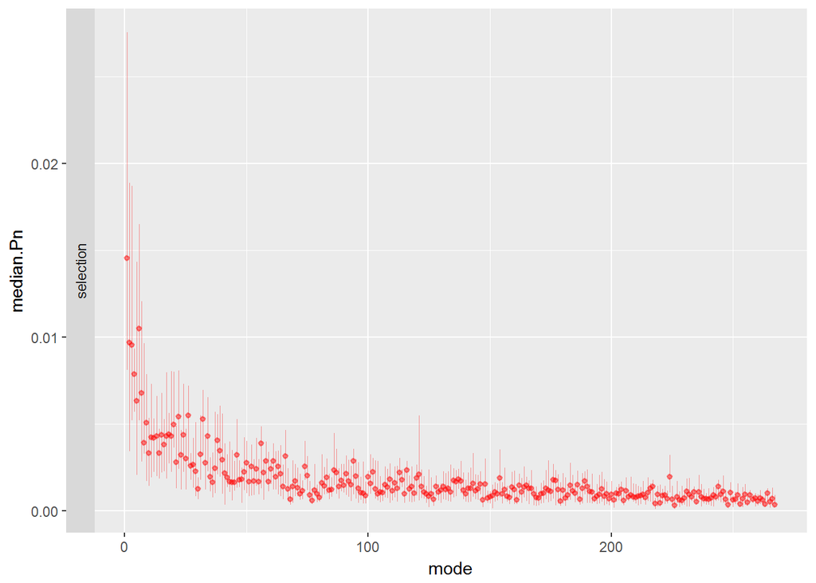

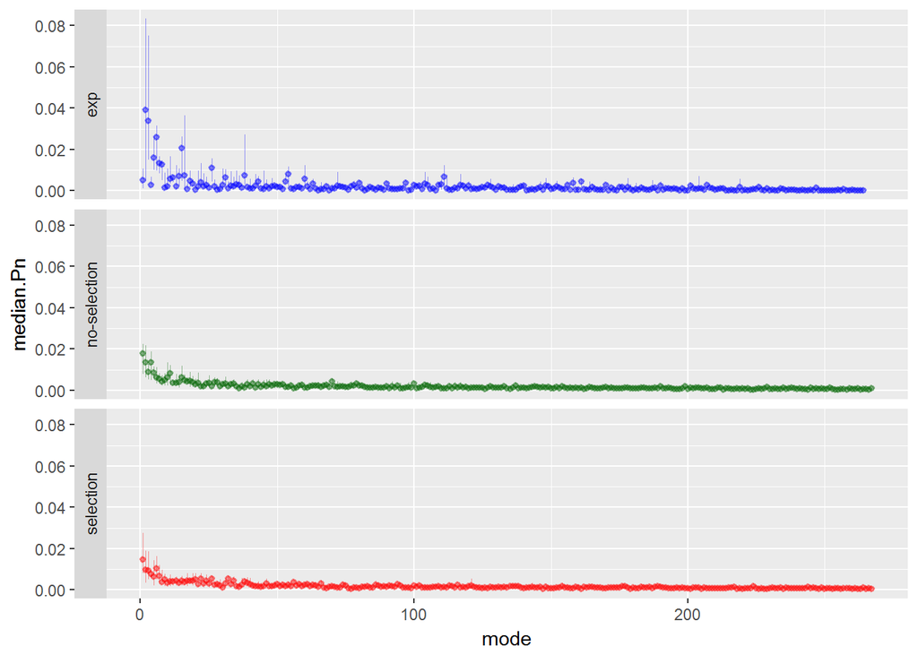

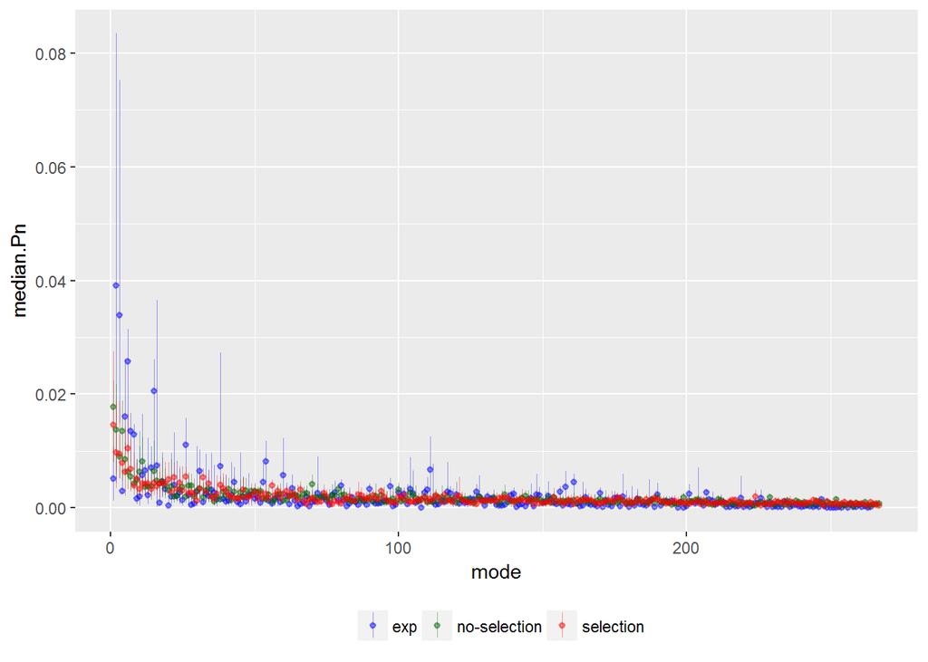

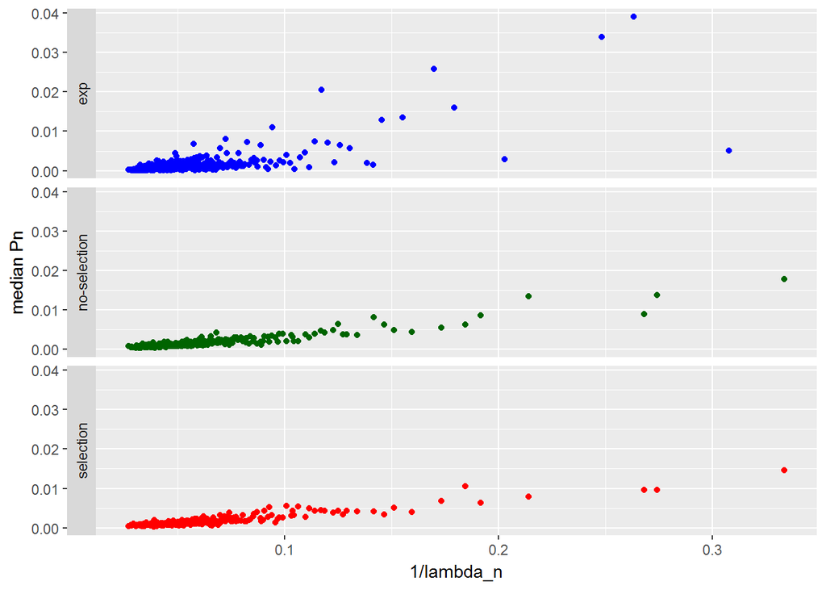

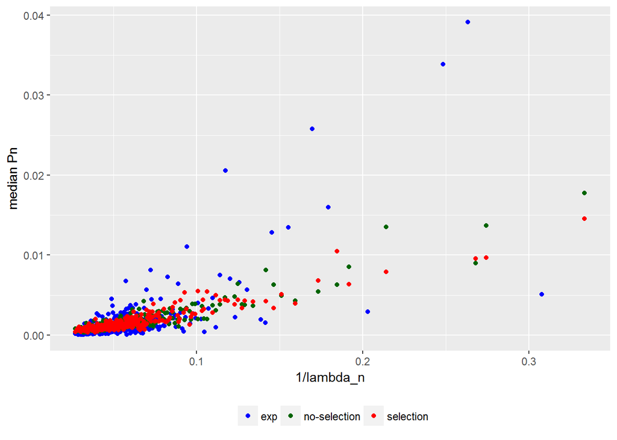

(calculated for the first 100 modes)

| comparison.Pn.Sn2 | R |
| --- | --- |
| exp | 0.70 |
| mut | 0.92 |
| medium | 0.91 |

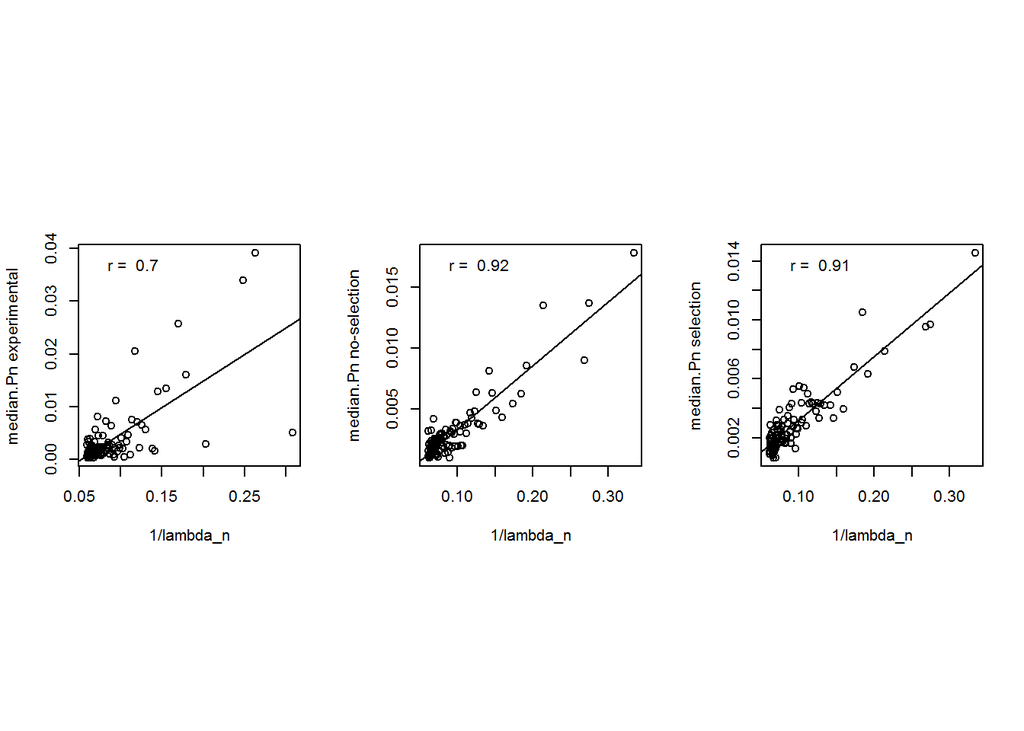

| comparison.Pn.100.modes | R |
| --- | --- |
| exp vs mut | 0.57 |
| exp vs medium | 0.64 |
| mut vs medium | 0.82 |

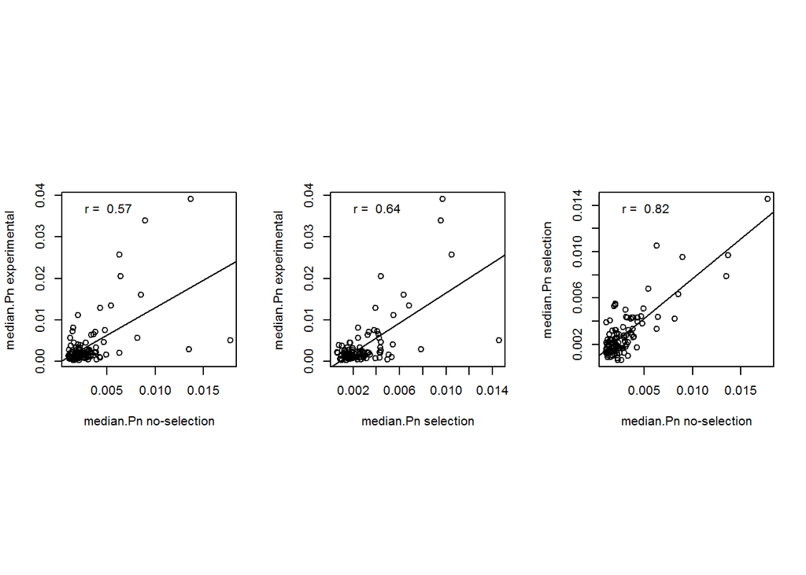